# Importing libraries

## 5.Bar Plot

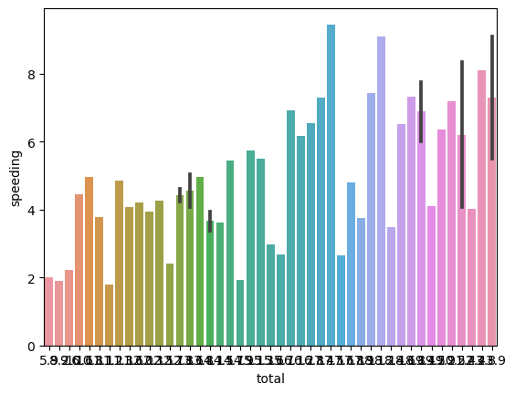

```python
sns.barplot(data=df,x="total",y="speeding")
```

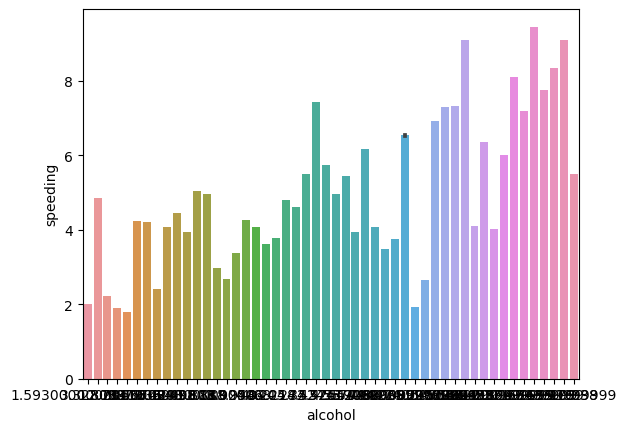

```python
sns.barplot(data=df,x="alcohol",y="speeding")
```

Inference: The barplot displays the mean speeding crashes for different levels of alcohol consumption, here the alcohol consumption is directly proportional to speeding crashes

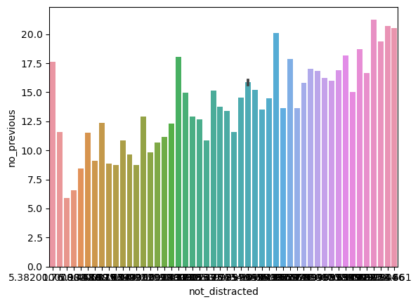

```python
sns.barplot(data=df,x="not_distracted",y="no_previous")
```

Inference: The barplot displays the mean no_previous crashes for different levels of not_distracted consumption, here the not_distracted consumption is directly proportional to no_previous crashes

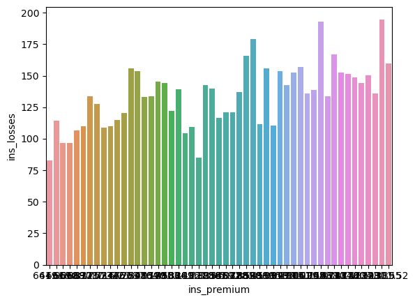

```python
sns.barplot(data=df,x="ins_premium",y="ins_losses")
```

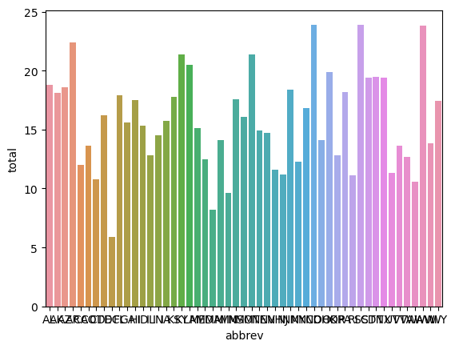

```python
sns.barplot(data=df,x="abbrev",y="total")
```

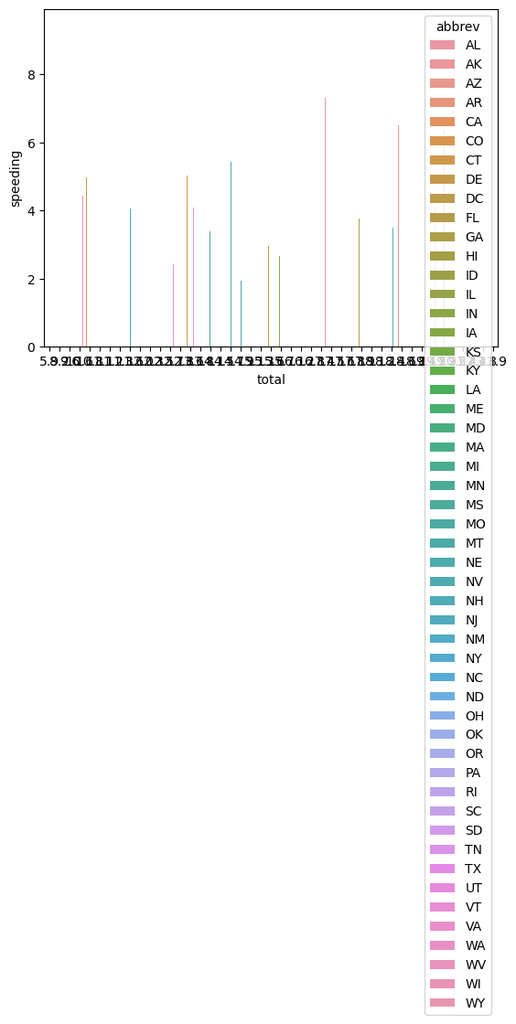

```python
sns.barplot(data=df,x="total",y="speeding",hue="abbrev")
```

Inference: The barplot displays the mean speeding crashes for different levels of total consumption, here the total consumption is directly proportional to speeding crashes.

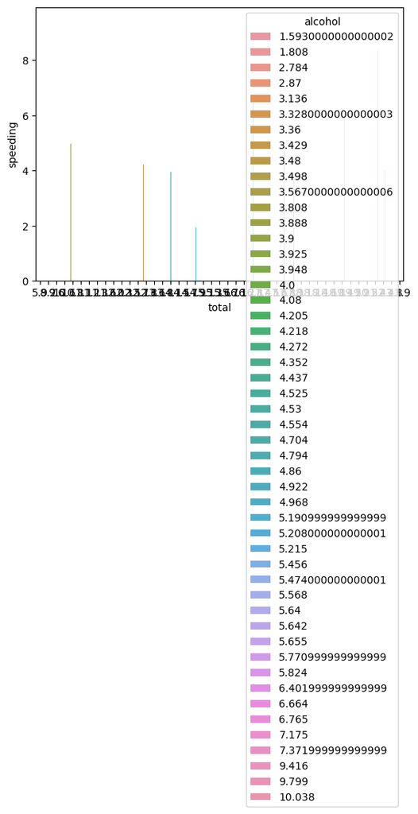

```python
sns.barplot(data=df,x="total",y="speeding",hue="alcohol")
```

Inference: The barplot displays the mean speeding crashes for different levels of total consumption, here the total consumption is directly proportional to speeding crashes.

[figure not shown]

```python
sns.barplot(data=df,x="ins_premium",y="ins_losses",hue="not_distracted")
```

[figure not shown]

```python
sns.barplot(data=df,x="no_previous",y="not_distracted",hue="total")
```

Inference: The barplot displays the mean not_distracted crashes for different levels of no_previous consumption, here the no_previous consumption is directly proportional to not_distracted crashes.

## 6.Joint Plot

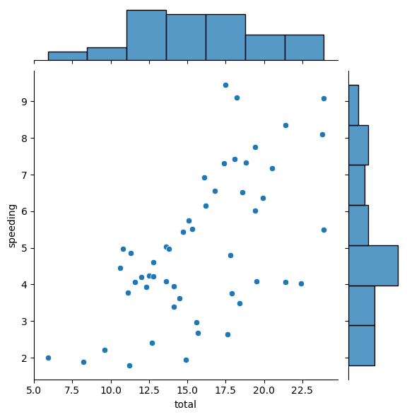

```python
sns.jointplot(x="total",y="speeding",data=df)
```

Inference:Form the jointplot we can say that total and speeding crashes are directly proportional.

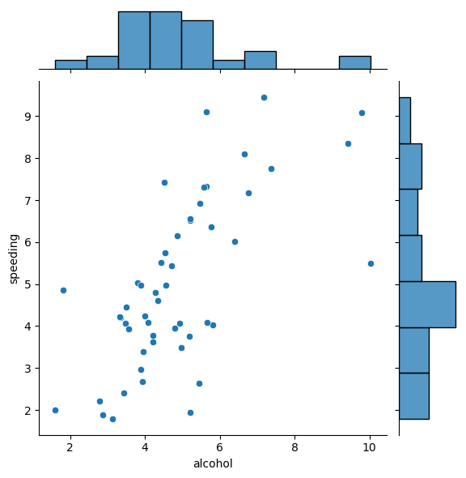

```python
sns.jointplot(x="alcohol",y="speeding",data=df)
```

Inference:Form the jointplot we can say that alcohol and speeding crashes are directly proportional.

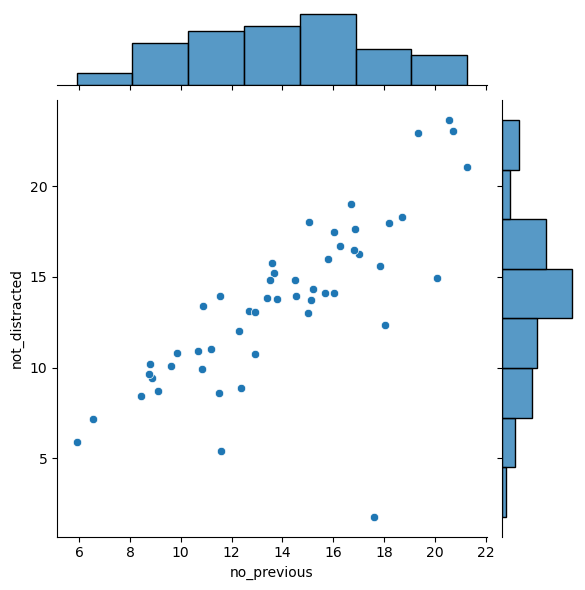

```python
sns.jointplot(x="no_previous",y="not_distracted",data=df)
```

Inference:Form the jointplot we can say that no_previous and not_distracted crashes are directly proportional.

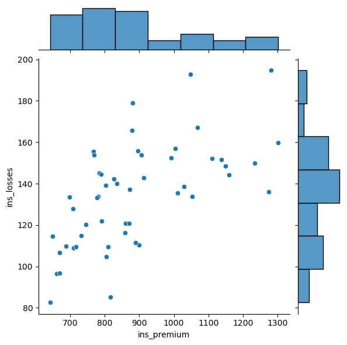

```python
sns.jointplot(x="ins_premium",y="ins_losses",data=df)
```

Inference:Form the jointplot we can say that ins_premium and ins_losses crashes are directly proportional.

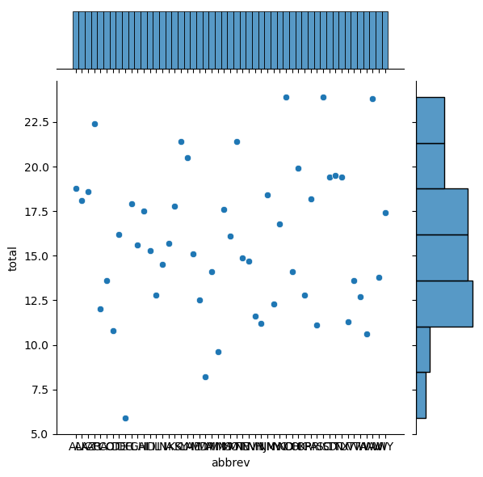

```python
sns.jointplot(x="abbrev",y="total",data=df)
```

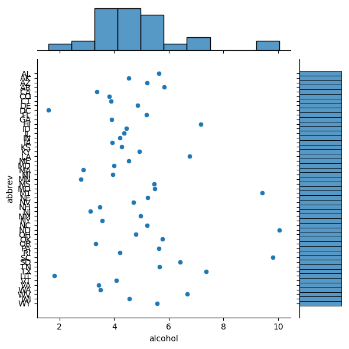

```python
sns.jointplot(x="alcohol",y="abbrev",data=df)
```

## 7. Box Plot

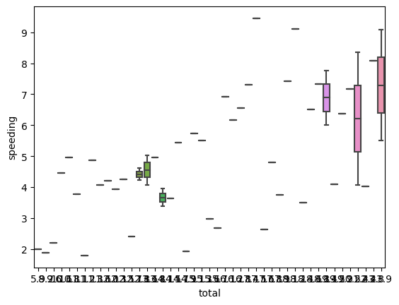

```python
sns.boxplot(x="total",y="speeding",data=df)
```

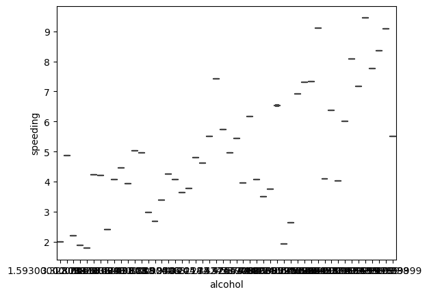

```python
sns.boxplot(x="alcohol",y="speeding",data=df)
```

## 8.pie Chart

[output not shown]

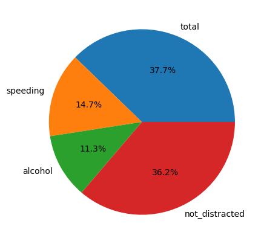

```python
import matplotlib.pyplot as plt
labels = ["total","speeding","alcohol","not_distracted"]
numbers = [18.8,7.332,5.640,18.048]
fig = plt.figure()
axes1=fig.add_axes([0.1,0.1,0.8,0.8])  #[Left,bottom,width,height]
axes1.pie(numbers,labels = labels,autopct="%0.1f%%")
```

The inferences:pie chart illustrates the distribution of car crash causes, highlighting the speeding,alcohol,total,not_distracted.

[output not shown]

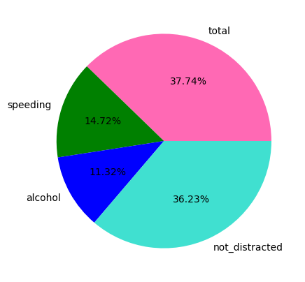

```python
import matplotlib.pyplot as plt
labels = ["total","speeding","alcohol","not_distracted"]
numbers = [18.8,7.332,5.640,18.048]
fig = plt.figure()
axes1=fig.add_axes([0.1,0.1,0.8,0.8])  #[Left,bottom,width,height]
axes1.pie(numbers,labels = labels,autopct="%0.2f%%",colors=["Hotpink","green","blue","turquoise"])
```

Inferences:pie chart illustrates the distribution of car crash causes, highlighting the speeding,alcohol,total,not_distracted.

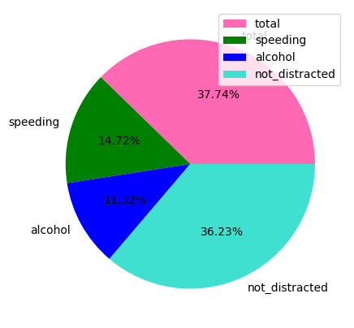

```python
import matplotlib.pyplot as plt
labels = ["total","speeding","alcohol","not_distracted"]
numbers = [18.8,7.332,5.640,18.048]
fig = plt.figure()
axes1=fig.add_axes([0.1,0.1,0.8,0.8])  #[Left,bottom,width,height]
axes1.pie(numbers,labels = labels,autopct="%0.2f%%",colors=["Hotpink","green","blue","turquoise"])
axes1.legend()
```

The inferences:pie chart illustrates the distribution of car crash causes, highlighting the speeding,alcohol,total,not_distracted.

```
 [Text(0.4509931830081761, 1.1120274946601607, 'total'),
```

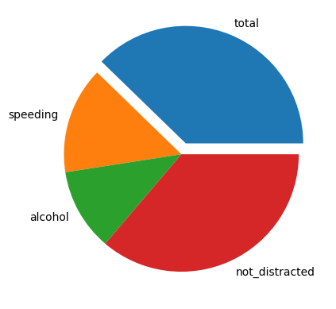

```python
Explode = [0.1,0,0,0]
plt.pie(numbers,labels=labels,explode=Explode)
```

The inferences:pie chart illustrates the distribution of car crash causes, highlighting the speeding,alcohol,total,not_distracted.

```
 [Text(0.4509931830081761, 1.1120274946601607, 'total'),
```

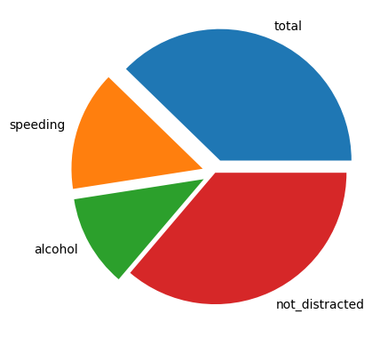

```python
Explode = [0.1,0.1,0.1,0]
plt.pie(numbers,labels=labels,explode=Explode)
```

The inferences:pie chart illustrates the distribution of car crash causes, highlighting the speeding,alcohol,total,not_distracted.

## 9.Heat MaP

```python
corr=df.corr()
corr
```

|  | total | speeding | alcohol | not_distracted | no_previous | ins_premium | ins_losses |
| --- | --- | --- | --- | --- | --- | --- | --- |
| total | 1.000000 | 0.611548 | 0.852613 | 0.827560 | 0.956179 | -0.199702 | -0.036011 |
| speeding | 0.611548 | 1.000000 | 0.669719 | 0.588010 | 0.571976 | -0.077675 | -0.065928 |
| alcohol | 0.852613 | 0.669719 | 1.000000 | 0.732816 | 0.783520 | -0.170612 | -0.112547 |
| not_distracted | 0.827560 | 0.588010 | 0.732816 | 1.000000 | 0.747307 | -0.174856 | -0.075970 |
| no_previous | 0.956179 | 0.571976 | 0.783520 | 0.747307 | 1.000000 | -0.156895 | -0.006359 |
| ins_premium | -0.199702 | -0.077675 | -0.170612 | -0.174856 | -0.156895 | 1.000000 | 0.623116 |
| ins_losses | -0.036011 | -0.065928 | -0.112547 | -0.075970 | -0.006359 | 0.623116 | 1.000000 |

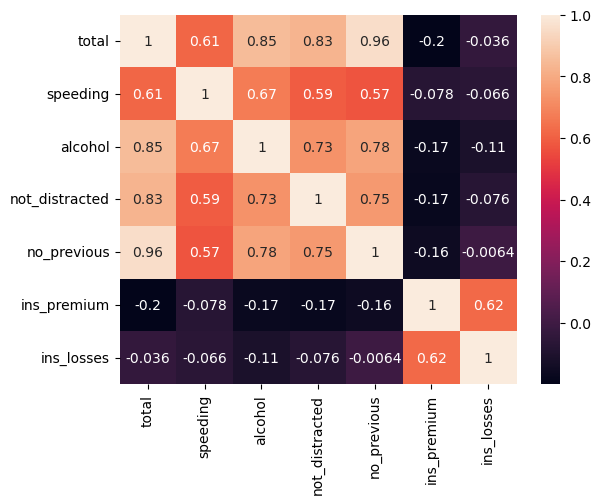

```python
sns.heatmap(corr,annot=True)
```

Inference: From the graph we can say that it is positively, negatively and neutrally corrlated

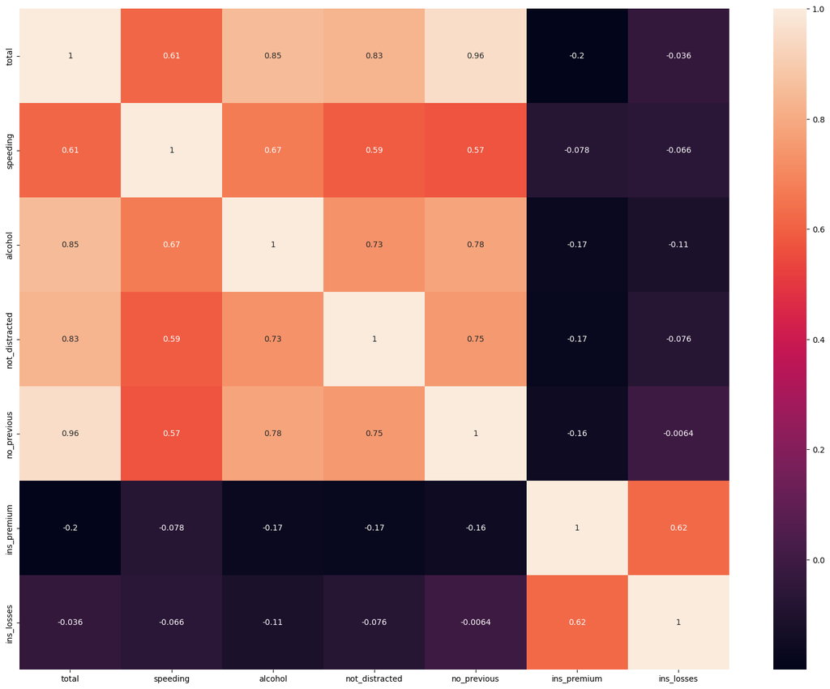

```python
plt.subplots(figsize=(20,15))
sns.heatmap(corr,annot=True)
```

Inference: From the graph we can say that it is positively, negatively and neutrally corrlated

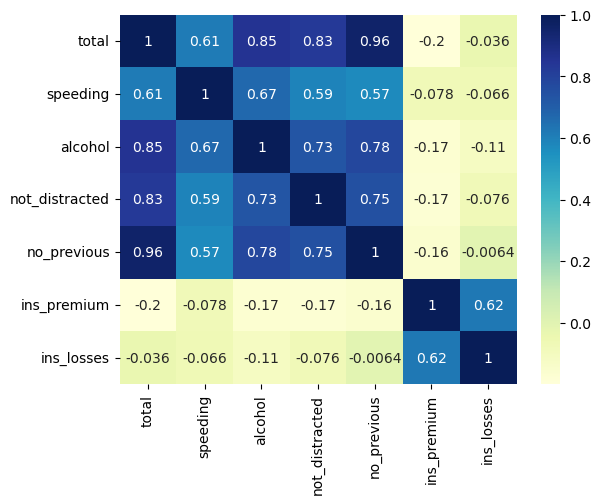

```python
sns.heatmap(corr,annot=True,cmap="YlGnBu")
```

Inference: From the graph we can say that it is positively, negatively and neutrally corrlated with YlGnBu

## 10. Violin Plot

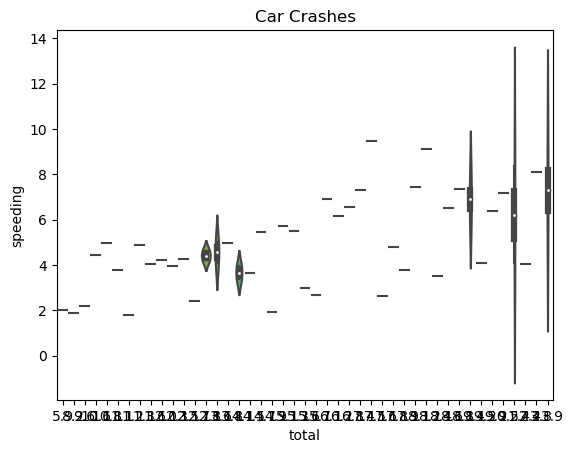

```python
sns.violinplot(x='total', y='speeding', data=df)

# Customize the plot
plt.title('Car Crashes')
plt.xlabel('total')
plt.ylabel('speeding')

# Display the plot
plt.show()
```

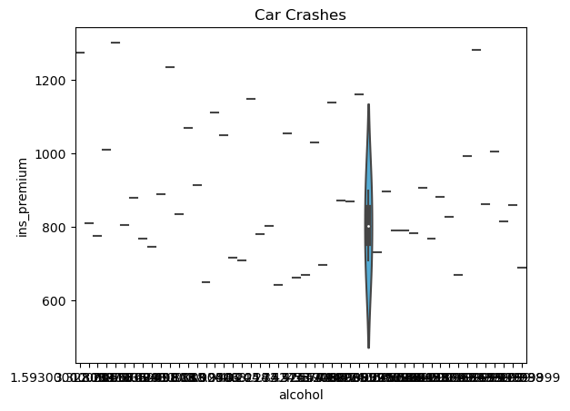

```python
sns.violinplot(x='alcohol', y='ins_premium', data=df)

# Customize the plot
plt.title('Car Crashes')
plt.xlabel('alcohol')
plt.ylabel('ins_premium')

# Display the plot
plt.show()
```

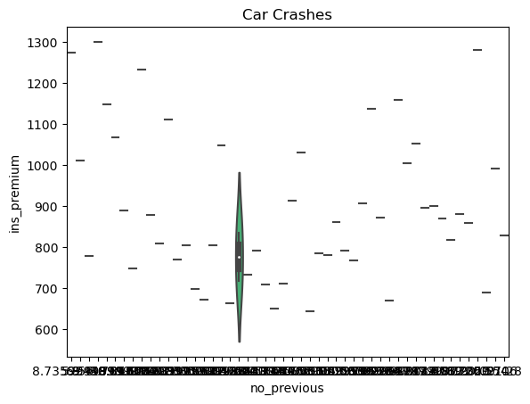

```python
sns.violinplot(x='no_previous', y='ins_premium', data=df)

# Customize the plot
plt.title('Car Crashes')
plt.xlabel('no_previous')
plt.ylabel('ins_premium')

# Display the plot
plt.show()
```

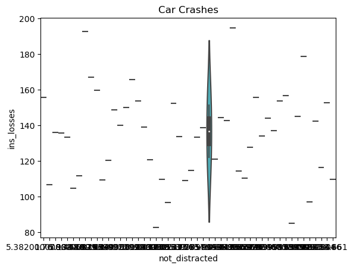

```python
sns.violinplot(x='not_distracted', y='ins_losses', data=df)

# Customize the plot
plt.title('Car Crashes')
plt.xlabel('not_distracted')
plt.ylabel('ins_losses')

# Display the plot
plt.show()
```

## 11. Pair Plot

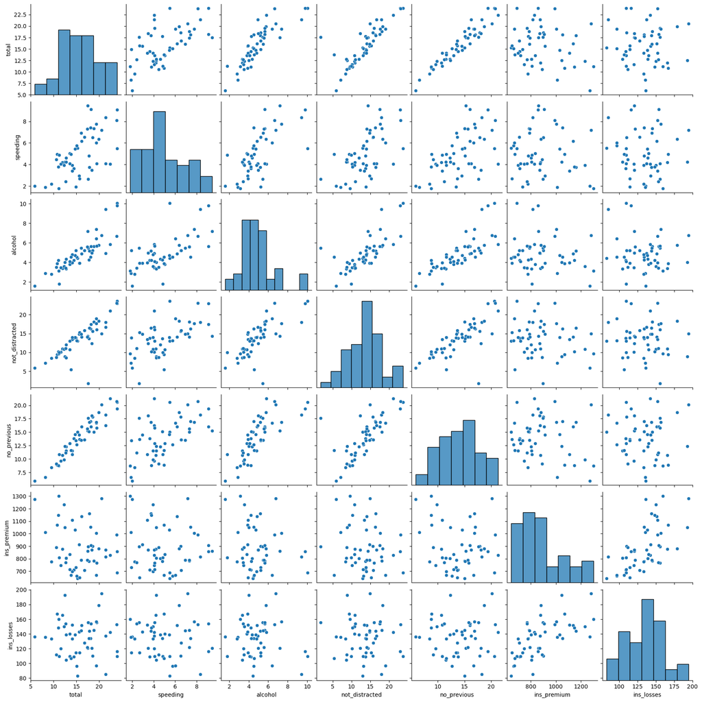

```python
sns.pairplot(df)
```

Inference:The pair plot provides a comprehensive visualization of the relationships and correlations between multiple variables of car crashes

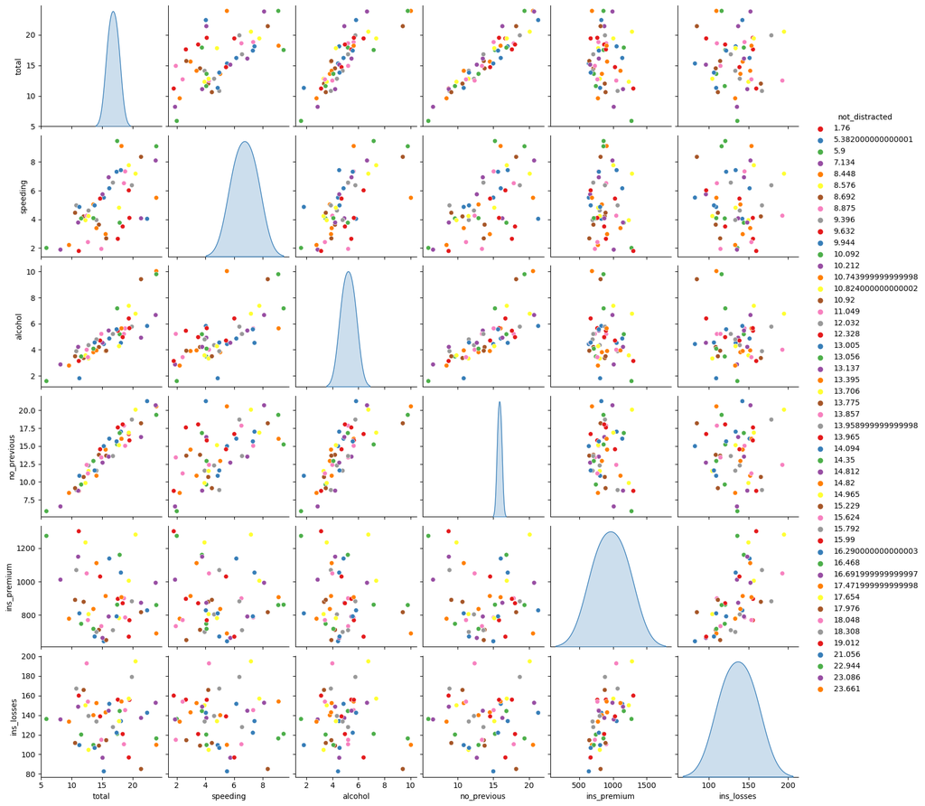

```python
sns.pairplot(df,hue="not_distracted",palette = "Set1")
```

Inference:The pair plot provides a comprehensive visualization of the relationships and correlations between multiple variables of car crashes

## 12.Linear Regression Plot

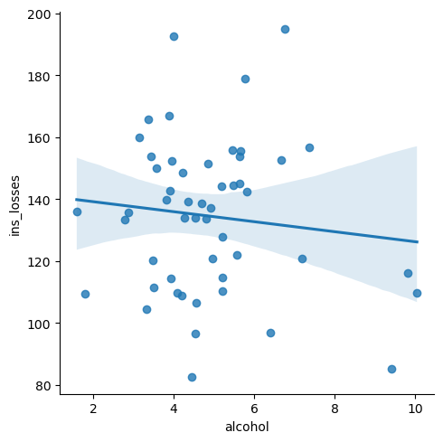

```python
sns.lmplot(x="alcohol",y="ins_losses",data=df)
```

Inference:This plot visually represents the relationship and trend between two variables alcohol and ins_losses, indicating the direction of their linear association.

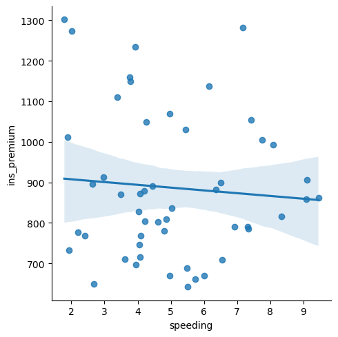

```python
sns.lmplot(x="speeding",y="ins_premium",data=df)
```

Inference:This plot visually represents the relationship and trend between two variables speeding and ins_premimum, indicating the direction of their linear association

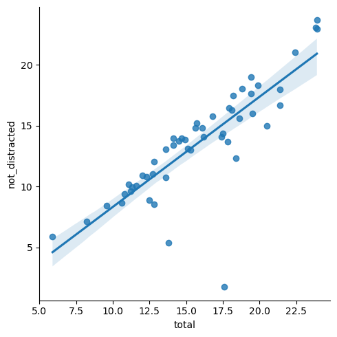

```python
sns.lmplot(x="total",y="not_distracted",data=df)
```

Inference:This plot visually represents the relationship and trend between two variables total and not_distracted, indicating the direction of their linear association

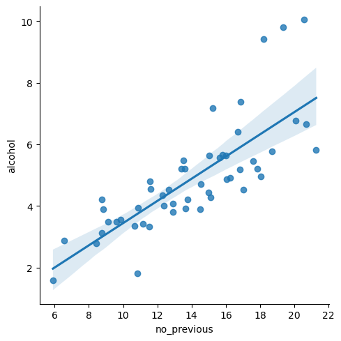

```python
sns.lmplot(x="no_previous",y="alcohol",data=df)
```

Inference:This plot visually represents the relationship and trend between two variables no_previous and alcohol, indicating the direction of their linear association

## 13.Count plot

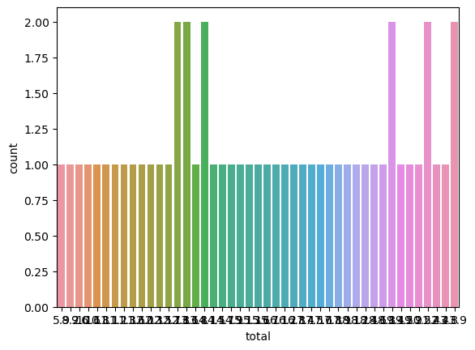

```python
sns.countplot(x='total',data=df)
```

[figure not shown]

```python
sns.countplot(x='total', hue = 'alcohol',data=df)
```

[figure not shown]

```python
sns.countplot(x='total', hue = 'alcohol',data=df)
```